# UnsupervisedLearningRM

## Ralchukwu Mogbogu

### Assignment 8: Unsupervised Learning

### ANLY 530-50-A

### 12/31/2025

```python
import pandas as pd
wholesale = pd.read_csv("Wholesale_customers_data.csv")
wholesale.head()
```

|  | Fresh | Milk | Grocery | Frozen | Detergents_Paper | Delicassen |
| --- | --- | --- | --- | --- | --- | --- |
| 0 | 12669 | 9656 | 7561 | 214 | 2674 | 1338 |
| 1 | 7057 | 9810 | 9568 | 1762 | 3293 | 1776 |
| 2 | 6353 | 8808 | 7684 | 2405 | 3516 | 7844 |
| 3 | 13265 | 1196 | 4221 | 6404 | 507 | 1788 |
| 4 | 22615 | 5410 | 7198 | 3915 | 1777 | 5185 |

```python
wholesale.dtypes
```

|  | 0 |
| --- | --- |
| Fresh | int64 |
| Milk | int64 |
| Grocery | int64 |
| Frozen | int64 |
| Detergents_Paper | int64 |
| Delicassen | int64 |

**dtype:** object

```python
wholesale.describe()
```

|  | Fresh | Milk | Grocery | Frozen | Detergents_Paper | Delicassen |
| --- | --- | --- | --- | --- | --- | --- |
| count | 440.000000 | 440.000000 | 440.000000 | 440.000000 | 440.000000 | 440.000000 |
| mean | 12000.297727 | 5796.265909 | 7951.277273 | 3071.931818 | 2881.493182 | 1524.870455 |
| std | 12647.328865 | 7380.377175 | 9503.162829 | 4854.673333 | 4767.854448 | 2820.105937 |
| min | 3.000000 | 55.000000 | 3.000000 | 25.000000 | 3.000000 | 3.000000 |
| 25% | 3127.750000 | 1533.000000 | 2153.000000 | 742.250000 | 256.750000 | 408.250000 |
| 50% | 8504.000000 | 3627.000000 | 4755.500000 | 1526.000000 | 816.500000 | 965.500000 |
| 75% | 16933.750000 | 7190.250000 | 10655.750000 | 3554.250000 | 3922.000000 | 1820.250000 |
| max | 112151.000000 | 73498.000000 | 92780.000000 | 60869.000000 | 40827.000000 | 47943.000000 |

### 1) Use following code, to fit a normal distribution and plot it for the variable “Fresh”:

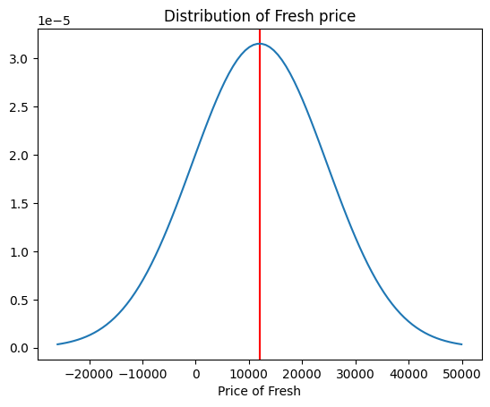

```python
import numpy as np
import matplotlib.pyplot as plt
from scipy.stats import norm
mu = wholesale['Fresh'].mean()
sigma = wholesale['Fresh'].std()
x = np.linspace(mu-3*sigma, mu+3*sigma, 100)
plt.axvline(x=mu,color='r')
plt.plot(x, norm.pdf(x,mu,sigma))
plt.title('Distribution of Fresh price')
plt.xlabel('Price of Fresh')
plt.show()
```

### 2) There are some outliers in data, use following code to drop the outliers in data.

For each column, first it computes the Z-score of each value in the column, relative to the column mean and standard deviation. Then is takes the absolute of Z-score because the direction does not matter, only if it is below the threshold. all(axis=1) ensures that for each row, all column satisfy the constraint. Finally, result of this condition is used to index the dataframe

```python
import numpy as np
from scipy import stats
wholesale_new = wholesale[(np.abs(stats.zscore(wholesale)) < 3).all(axis=1)]
```

```python
#just to make sure that the outliers actually got removed
print("OG data shape:", wholesale.shape)
print("Post outlier removal", wholesale_new.shape)
```

```
OG data shape: (440, 6)
Post outlier removal (414, 6)
```

```python
wholesale_new.describe()
```

|  | Fresh | Milk | Grocery | Frozen | Detergents_Paper | Delicassen |
| --- | --- | --- | --- | --- | --- | --- |
| count | 414.000000 | 414.000000 | 414.000000 | 414.000000 | 414.000000 | 414.000000 |
| mean | 10711.758454 | 4871.920290 | 6814.043478 | 2549.898551 | 2373.393720 | 1237.939614 |
| std | 9819.217756 | 4555.665546 | 6456.160715 | 2916.683284 | 3208.707909 | 1217.399162 |
| min | 3.000000 | 55.000000 | 3.000000 | 25.000000 | 3.000000 | 3.000000 |
| 25% | 3063.250000 | 1477.750000 | 2116.000000 | 676.750000 | 252.750000 | 395.000000 |
| 50% | 8040.000000 | 3530.000000 | 4528.000000 | 1447.000000 | 772.000000 | 881.000000 |
| 75% | 15657.000000 | 6908.500000 | 9762.250000 | 3204.250000 | 3660.500000 | 1681.750000 |
| max | 49063.000000 | 25862.000000 | 34792.000000 | 16919.000000 | 17120.000000 | 7844.000000 |

### 3) Draw the Elbow curve. What is the best value for k?

The elbow curve plot using Distortion, the optimal/best value for K is 3 as the wcss (within-cluster sum of squares) appears to slow down at the elbow bend on 3; i.e, K = 3.

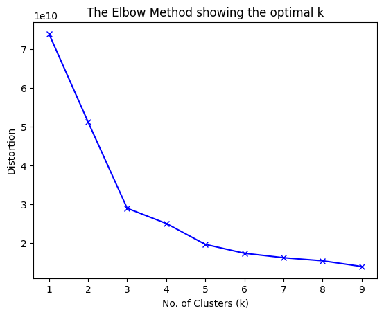

```python
from sklearn.cluster import KMeans

distortions = []
K = range(1, 10)

for k in K:
  kmeanModel = KMeans(n_clusters=k, random_state=21).fit(wholesale_new)
  kmeanModel.fit(wholesale_new)
  distortions.append(kmeanModel.inertia_)

#Elbow plot using distortion
plt.plot(K, distortions, 'bx-')
plt.xlabel('No. of Clusters (k)')
plt.ylabel('Distortion')
plt.title('The Elbow Method showing the optimal k')
plt.show()
```

### 4) Use the k that you found above and design your kmeans model and call it kmeans.

```python
#i think i did this already in task 3, but I will rename the code
kmeans = KMeans(n_clusters=3, random_state=21)
kmeans.fit(wholesale_new)
```

```
KMeans(n_clusters=3, random_state=21)
```

### 5) What are the centroids values for this model?

```python
centroids_val = kmeans.cluster_centers_
print(centroids_val)

#this just shows an array of numbers but not clearly which belongs
#to what clusters of the groups in the "wholesale" data;
#i may have to convert it into a DataFrame to do clearly state what belongs to what
```

```
[[25060.34343434  4000.26262626  5149.13131313  3771.44444444
   1127.15151515  1573.74747475]
 [ 4522.20454545 10535.46590909 16786.48863636  1424.95454545
   7265.20454545  1515.5       ]
 [ 6853.48017621  3056.51101322  3674.18061674  2453.25550661
   1020.52422907   983.88546256]]
```

```python
centers = pd.DataFrame(kmeans.cluster_centers_, columns = wholesale_new.columns)
print(centers)

#I prefer this better because it clearly shows which variables
#and clusters the center values belong to.
```

```
          Fresh          Milk       Grocery       Frozen  Detergents_Paper  \
0  25060.343434   4000.262626   5149.131313  3771.444444       1127.151515
1   4522.204545  10535.465909  16786.488636  1424.954545       7265.204545
2   6853.480176   3056.511013   3674.180617  2453.255507       1020.524229

    Delicassen
0  1573.747475
1  1515.500000
2   983.885463
```

### 6) Write 2 sentences or more about what you can learn from this model.

This Unsupervised Learning algorithm or more specifically Kmeans-cluster model defines customers hidden purchase patterns and spending habits.

The elbow plot shows that the best number of clusters is 3, and it is clearly a case of k = 3 due to the distortion reducing sharply at the bend of 3 before it levels off.

The Clusters and the centroid values give a transparent outlook by separating the customers in a way that shows their spending habits. Overall, from this model we can then form a conclusion on hidden purchasing patterns from wholesale preferences to spending habits. This will help in personalized customer recommendations, predictions and even targeted marketing campaigns; and a bonus in budgeting and resource allocation for grocery/wholesale stores.